# 3_1_Beta Estimation

Wenqiang Li

2024-02-19

在本章中，我们介绍金融经济学中的一个重要概念：个股对市场投资组合变化的暴露程度。根据Sharpe ( 1964 )、Lintner ( 1965 )和Mossin ( 1966 )的资本资产定价模型 (CAPM) ，预期资产回报的横截面变化应该是资产超额回报与资产超额回报之间协方差的函数。市场投资组合的超额回报。超额市场收益对超额股票收益的回归系数通常称为市场贝塔值。我们展示了市场贝塔值的估计程序。我们不会详细介绍市场贝塔值的基础，而只是参考[CAPM](https://translate.google.com/website?sl=auto&tl=zh-CN&hl=zh-CN&client=webapp&u=https://en.wikipedia.org/wiki/Capital_asset_pricing_model)的任何处理方式以获取更多信息。相反，我们提供有关用于计算结果的所有函数的详细信息。特别是，我们利用有用的计算概念：滚动窗口估计和并行化。

我们在本章中使用以下 R 包：

```r
library(tidyverse)
library(RSQLite)
library(scales)
library(slider)
library(furrr)
```

与前面的章节相比，我们引入了`slider` （[Vaughan 2021](https://www-tidy--finance-org.translate.goog/r/beta-estimation.html?_x_tr_sl=auto&_x_tr_tl=zh-CN&_x_tr_hl=zh-CN&_x_tr_pto=wapp#ref-slider)）滑动窗口函数，以及`furrr` （[Vaughan 和 Dancho 2022](https://www-tidy--finance-org.translate.goog/r/beta-estimation.html?_x_tr_sl=auto&_x_tr_tl=zh-CN&_x_tr_hl=zh-CN&_x_tr_pto=wapp#ref-furrr)）并行应用映射函数。

## **使用月度回报估算贝塔值**

估计过程基于滚动窗口估计，我们可以使用每月或每日收益以及不同的窗口长度。首先，让我们开始从[访问和管理财务数据](https://www-tidy--finance-org.translate.goog/r/accessing-and-managing-financial-data.html?_x_tr_sl=auto&_x_tr_tl=zh-CN&_x_tr_hl=zh-CN&_x_tr_pto=wapp)以及[WRDS、CRSP 和 Compustat](https://www-tidy--finance-org.translate.goog/r/wrds-crsp-and-compustat.html?_x_tr_sl=auto&_x_tr_tl=zh-CN&_x_tr_hl=zh-CN&_x_tr_pto=wapp)`SQLite`中介绍的数据库加载每月 CRSP 数据。

```r
tidy_finance <- dbConnect(
  SQLite(),
  "/Users/desmondli/Desktop/College/互联网与数字经济/赵宣凯老师/tidy finance/tidy_finance.sqlite",
  extended_types = TRUE
)

crsp_monthly <- tbl(tidy_finance, "crsp_monthly") |>
  select(permno, month, industry, ret_excess) |>
  collect()

factors_ff3_monthly <- tbl(tidy_finance, "factors_ff_monthly") |>
  select(month, mkt_excess) |>
  collect()

crsp_monthly <- crsp_monthly |>
  left_join(factors_ff3_monthly, join_by(month))
```

估计 CAPM 回归系数

$$r_{i,t}-r_{f,t}=\alpha_i+\beta_i(r_{m,t}-r_{f,t})+\varepsilon_{i,t}$$

```r
fit <- lm(ret_excess ~ mkt_excess,
  data = crsp_monthly |>
    filter(permno == "14593")
)

summary(fit)
```

```
##
## Call:
## lm(formula = ret_excess ~ mkt_excess, data = filter(crsp_monthly,
##     permno == "14593"))
##
## Residuals:
##      Min       1Q   Median       3Q      Max
## -0.51689 -0.05983  0.00008  0.06363  0.39440
##
## Coefficients:
##             Estimate Std. Error t value Pr(>|t|)
## (Intercept)  0.01034    0.00521   1.985   0.0477 *
## mkt_excess   1.39419    0.11576  12.043   <2e-16 ***
## ---
## Signif. codes:  0 '***' 0.001 '**' 0.01 '*' 0.05 '.' 0.1 ' ' 1
##
## Residual standard error: 0.1141 on 490 degrees of freedom
## Multiple R-squared:  0.2284, Adjusted R-squared:  0.2268
## F-statistic:   145 on 1 and 490 DF,  p-value: < 2.2e-16
```

`lm()`返回一个类的对象`lm`，其中包含我们通常关心的线性模型的所有信息。`summary()`返回估计参数的概述。`coefficients(fit)`将仅返回估计系数。上面的输出表明，苹果公司的行为与市场的预期高于一$\hat{\beta_i}\approx1.4$。

## **滚动窗口估计**

在我们估计了一个例子的回归系数后，我们缩放了估计beta一个完全不同的水平，并对整个 CRSP 样本执行滚动窗口估计。以下函数对至少包含观测值的数据框（或其一部分）实现 CAPM 回归，`min_obs`以避免时间序列太短时出现巨大波动。如果违反条件，即时间序列太短，则函数返回缺失值。

```r
estimate_capm <- function(data, min_obs = 1) {
  if (nrow(data) < min_obs) {
    beta <- as.numeric(NA)
  } else {
    fit <- lm(ret_excess ~ mkt_excess, data = data)
    beta <- as.numeric(coefficients(fit)[2])
  }
  return(beta)
}
```

接下来，我们定义一个进行滚动估计的函数。该`slide_period`函数能够以简单的方式处理窗口输入中的月份。因此，我们避免使用任何时间序列包（例如，`zoo`）并转换数据以适合包函数，而是留在`tidyverse`.

以下函数获取输入数据并在`month`向量上滑动，仅考虑总共几个月`months`。该函数本质上执行三个步骤：(i) 排列所有行，(ii) 通过跨月份滑动来计算 beta，以及 (iii) 返回包含月份和相应 beta 估计值的小标题（在每日数据的情况下同样特别有用）。正如我们在下面进一步演示的，我们还可以将相同的函数应用于每日收益数据。

```r
roll_capm_estimation <- function(data, months, min_obs) {
  data <- data |>
    arrange(month)

  betas <- slide_period_vec(
    .x = data,
    .i = data$month,
    .period = "month",
    .f = ~ estimate_capm(., min_obs),
    .before = months - 1,
    .complete = FALSE
  )

  return(tibble(
    month = unique(data$month),
    beta = betas
  ))
}
```

在我们研究整个 CRSP 样本之前，让我们先关注几个知名公司的例子。

```r
examples <- tribble(
  ~permno, ~company,
  14593, "Apple",
  10107, "Microsoft",
  93436, "Tesla",
  17778, "Berkshire Hathaway"
)
```

如果我们想估计 Apple 的滚动测试版，我们可以使用`mutate()`.我们总共使用 5 年的数据，并需要至少 48 个月的返回数据来计算我们的贝塔值。如果您想计算不同时间段的贝塔值，请查看练习。

```r
beta_example <- crsp_monthly |>
  filter(permno == examples$permno[1]) |>
  mutate(roll_capm_estimation(pick(everything()), months = 60, min_obs = 48)) |>
  drop_na()
beta_example
```

```
## # A tibble: 445 × 6
##    permno month      industry      ret_excess mkt_excess  beta
##     <dbl> <date>     <chr>              <dbl>      <dbl> <dbl>
##  1  14593 1984-12-01 Manufacturing     0.170      0.0184  2.05
##  2  14593 1985-01-01 Manufacturing    -0.0108     0.0799  1.90
##  3  14593 1985-02-01 Manufacturing    -0.152      0.0122  1.88
##  4  14593 1985-03-01 Manufacturing    -0.112     -0.0084  1.89
##  5  14593 1985-04-01 Manufacturing    -0.0467    -0.0096  1.90
##  6  14593 1985-05-01 Manufacturing    -0.189      0.0509  1.76
##  7  14593 1985-06-01 Manufacturing     0.0305     0.0127  1.76
##  8  14593 1985-07-01 Manufacturing    -0.124     -0.0074  1.77
##  9  14593 1985-08-01 Manufacturing    -0.0606    -0.0102  1.78
## 10  14593 1985-09-01 Manufacturing     0.0440    -0.0454  1.71
## # ℹ 435 more rows
```

实际上，对任意数量的股票执行滚动窗口估计非常简单，我们在下面的代码块和结果[图 1](https://www-tidy--finance-org.translate.goog/r/beta-estimation.html?_x_tr_sl=auto&_x_tr_tl=zh-CN&_x_tr_hl=zh-CN&_x_tr_pto=wapp#fig-601)中将其可视化。

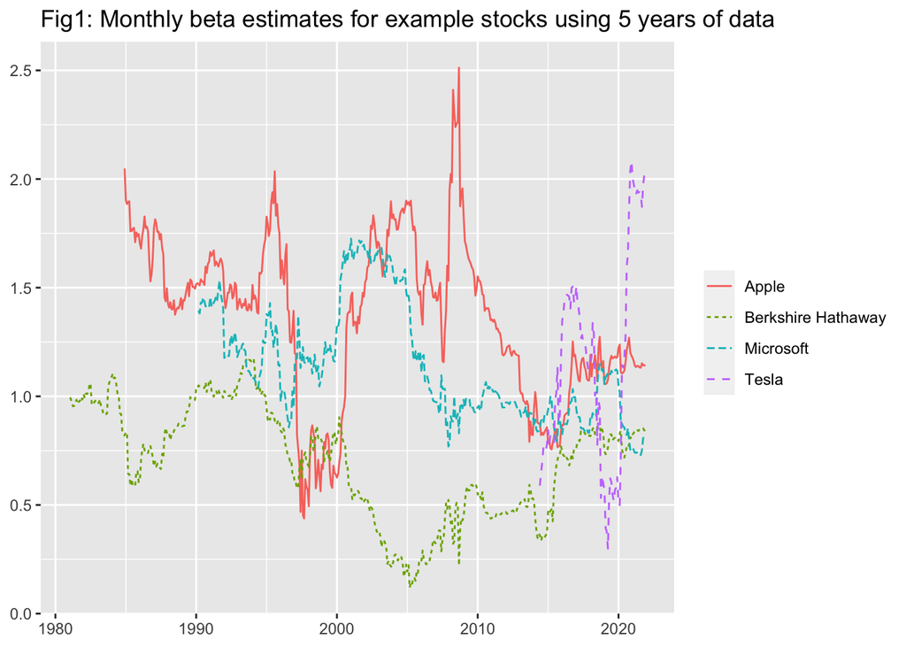

```r
beta_examples <- crsp_monthly |>
  inner_join(examples, join_by(permno)) |>
  group_by(permno) |>
  mutate(roll_capm_estimation(pick(everything()), months = 60, min_obs = 48)) |>
  ungroup() |>
  select(permno, company, month, beta) |>
  drop_na()

beta_examples |>
  ggplot(aes(
    x = month,
    y = beta,
    color = company,
    linetype = company)) +
  geom_line() +
  labs(
    x = NULL, y = NULL, color = NULL, linetype = NULL,
    title = "Fig1: Monthly beta estimates for example stocks using 5 years of data"
  )
```

## **并行滚动窗口估计**

`group_by()`尽管我们现在可以在整个 CRSP 样本上应用该函数，但我们建议不要这样做，因为它的计算成本相当高。请记住，我们必须对所有股票和时间段执行滚动窗口估计。然而，这个估计问题是利用并行化能力的理想场景。并行化意味着我们将执行滚动窗口估计的任务拆分为不同的工作线程（或本地计算机上的核心）。

首先，我们`nest()`通过数据`permno`。嵌套数据意味着我们现在有一个`permno`包含相应时间序列数据和标签的列表`industry`。对于非嵌套变量的每个唯一组合（即`permno`和 ），我们得到一行输出`industry`。

```r
crsp_monthly_nested <- crsp_monthly |>
  nest(data = c(month, ret_excess, mkt_excess))
crsp_monthly_nested
```

```
## # A tibble: 30,072 × 3
##    permno industry      data
##     <dbl> <chr>         <list>
##  1  10057 Manufacturing <tibble [437 × 3]>
##  2  10066 Services      <tibble [23 × 3]>
##  3  10067 Manufacturing <tibble [12 × 3]>
##  4  10068 Finance       <tibble [8 × 3]>
##  5  10069 Retail        <tibble [10 × 3]>
##  6  10070 Manufacturing <tibble [56 × 3]>
##  7  10071 Finance       <tibble [138 × 3]>
##  8  10072 Manufacturing <tibble [68 × 3]>
##  9  10028 Wholesale     <tibble [238 × 3]>
## 10  10028 Retail        <tibble [112 × 3]>
## # ℹ 30,062 more rows
```

*或者，我们可以通过排除不想*嵌套的变量来创建相同的嵌套数据，如以下代码块所示。然而，对于许多应用程序来说，需要显式地声明嵌套在`data`列表列中的变量，以便读者可以跟踪其中最终的内容。

```r
crsp_monthly_nested <- crsp_monthly |>
  nest(data = -c(permno, industry))
```

接下来，我们要将`roll_capm_estimation()`函数应用到每只股票。这种情况是 的理想用例`map()`，它将列表或向量作为输入并返回与输入长度相同的对象。在我们的例子中，`map()`返回一个数据框，其中包含每只股票的 beta 估计值的时间序列。因此，我们使用`unnest()`将输出列表转换为整洁的数据框。

```r
crsp_monthly_nested |>
  inner_join(examples, join_by(permno)) |>
  mutate(beta = map(
    data,
    ~ roll_capm_estimation(., months = 60, min_obs = 48)
  )) |>
  unnest(beta) |>
  select(permno, month, beta_monthly = beta) |>
  drop_na()
```

```
## # A tibble: 1,410 × 3
##    permno month      beta_monthly
##     <dbl> <date>            <dbl>
##  1  10107 1990-03-01         1.39
##  2  10107 1990-04-01         1.38
##  3  10107 1990-05-01         1.43
##  4  10107 1990-06-01         1.43
##  5  10107 1990-07-01         1.45
##  6  10107 1990-08-01         1.44
##  7  10107 1990-09-01         1.41
##  8  10107 1990-10-01         1.42
##  9  10107 1990-11-01         1.41
## 10  10107 1990-12-01         1.41
## # ℹ 1,400 more rows
```

```r
n_cores = availableCores()/2
plan(multisession, workers = n_cores)
```

使用八个核心，对大约 25,000 只股票的样本进行估计大约需要 20 分钟。当然，您可以通过使用更多内核来分担工作负载或使用更强大的内核来显着加快速度。注意到下面代码中的区别了吗？您所需要做的就是替换`map()`为`future_map()`.

```r
beta_monthly <- crsp_monthly_nested |>
  mutate(beta = future_map(
    data, ~ roll_capm_estimation(., months = 60, min_obs = 48)
  )) |>
  unnest(c(beta)) |>
  select(permno, month, beta_monthly = beta) |>
  drop_na()
```

## **使用每日收益估算贝塔值**

在我们提供 Beta 估计的一些描述性统计数据之前，我们还对每日 CRSP 样本进行了估计。根据应用程序的不同，您可以使用基于月度数据的较长期限 beta 估计值或基于每日收益的较短期限估计值。

首先，我们加载每日 CRSP 数据。请注意，与每月数据相比，样本较大，因此请确保有足够的可用内存。

```r
crsp_daily <- tbl(tidy_finance, "crsp_daily") |>
  select(permno, month, date, ret_excess) |>
  collect()
```

我们还需要每天的 Fama-French 市场超额收益。

```r
factors_ff3_daily <- tbl(tidy_finance, "factors_ff_daily") |>
  select(date, mkt_excess) |>
  collect()
```

我们确保只保留相关数据以节省内存空间。但是，请注意，您的计算机可能没有足够的内存来读取整个每日 CRSP 示例。在本例中，我们将向您推荐练习并尝试使用[WRDS、CRSP 和 Compustat](https://www-tidy--finance-org.translate.goog/r/wrds-crsp-and-compustat.html?_x_tr_sl=auto&_x_tr_tl=zh-CN&_x_tr_hl=zh-CN&_x_tr_pto=wapp)中的循环。

```r
crsp_daily <- crsp_daily |>
  inner_join(factors_ff3_daily, join_by(date)) |>
  select(permno, month, ret_excess, mkt_excess)
```

就像上面一样，我们嵌套数据以`permno`实现并行化。

```r
crsp_daily_nested <- crsp_daily |>
  nest(data = c(month, ret_excess, mkt_excess))
```

这是使用 的几个示例的估计结果`map()`。对于每日数据，我们使用与上面相同的函数，但只取 3 个月的数据，并且要求这几个月中至少有 50 个每日返回观测值。这些限制有助于我们检索有些平滑的系数估计。

```r
crsp_daily_nested |>
  inner_join(examples, join_by(permno)) |>
  mutate(beta_daily = map(
    data,
    ~ roll_capm_estimation(., months = 3, min_obs = 50)
  )) |>
  unnest(c(beta_daily)) |>
  select(permno, month, beta_daily = beta) |>
  drop_na()
```

```
## # A tibble: 1,591 × 3
##    permno month      beta_daily
##     <dbl> <date>          <dbl>
##  1  10107 1986-05-01      0.898
##  2  10107 1986-06-01      0.906
##  3  10107 1986-07-01      0.822
##  4  10107 1986-08-01      0.900
##  5  10107 1986-09-01      1.01
##  6  10107 1986-10-01      1.03
##  7  10107 1986-11-01      1.58
##  8  10107 1986-12-01      1.64
##  9  10107 1987-01-01      2.38
## 10  10107 1987-02-01      1.51
## # ℹ 1,581 more rows
```

为了完整起见，我们再次告诉会话使用多个工作线程进行并行化。

```r
plan(multisession, workers = n_cores)
```

现在，使用每日收益进行 beta 估计的代码块看起来与月度数据的代码块非常相似。使用八个核心和 16GB 内存，整个估计需要大约 30 分钟。

```r
beta_daily <- crsp_daily_nested |>
  mutate(beta_daily = future_map(
    data, ~ roll_capm_estimation(., months = 3, min_obs = 50)
  )) |>
  unnest(c(beta_daily)) |>
  select(permno, month, beta_daily = beta) |>
  drop_na()
```

## **比较 Beta 估计值**

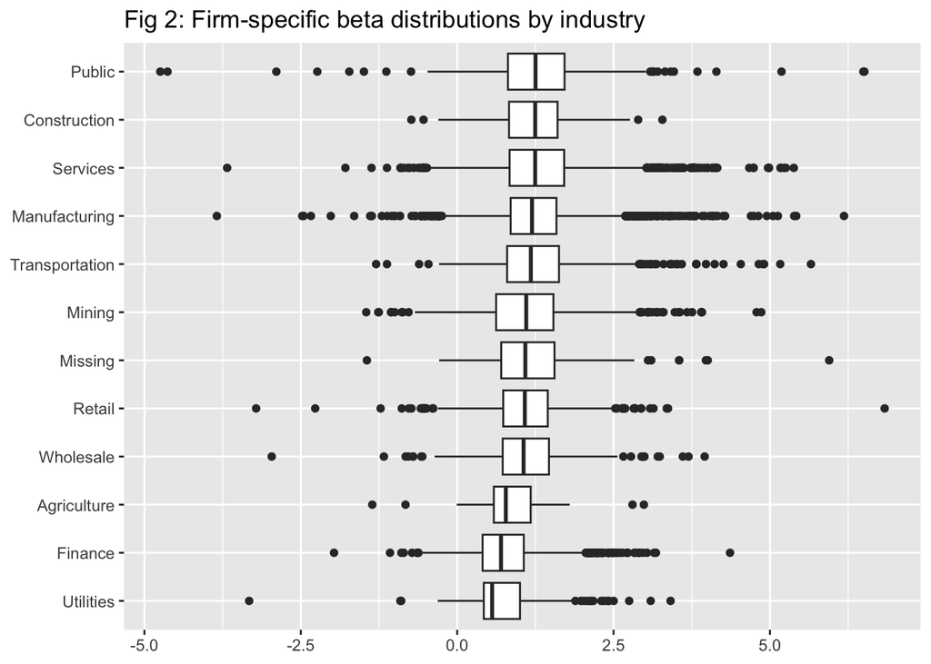

```r
crsp_monthly |>
  left_join(beta_monthly, join_by(permno, month)) |>
  drop_na(beta_monthly) |>
  group_by(industry, permno) |>
  summarize(beta = mean(beta_monthly),
            .groups = "drop") |>
  ggplot(aes(x = reorder(industry, beta, FUN = median), y = beta)) +
  geom_boxplot() +
  coord_flip() +
  labs(
    x = NULL, y = NULL,
    title = "Fig 2: Firm-specific beta distributions by industry"
  )
```

接下来，我们说明估计贝塔横截面的时间变化。[图 3](https://www-tidy--finance-org.translate.goog/r/beta-estimation.html?_x_tr_sl=auto&_x_tr_tl=zh-CN&_x_tr_hl=zh-CN&_x_tr_pto=wapp#fig-603)显示了估计贝塔值的每月十分位数（基于每月数据），并表明了一个有趣的模式：首先，贝塔值似乎随时间变化，因为在某些时期，所有十分位数都有明显的趋势。其次，样本显示股票之间的离散度增加的时期，即下十分位数减少而上十分位数增加，这表明对于某些股票来说，与市场的相关性增加，而对于另一些股票来说，与市场的相关性则减少。这里还要注意：贝塔系数为负的股票是罕见的例外。

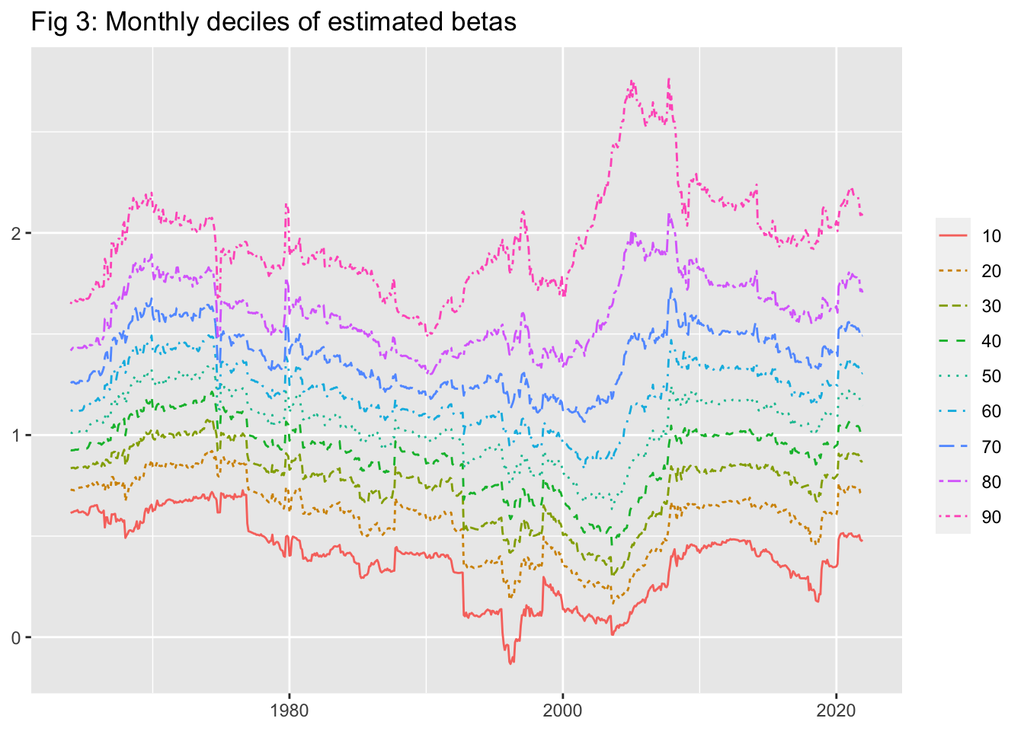

```r
beta_monthly |>
  drop_na(beta_monthly) |>
  group_by(month) |>
  reframe(
    x = quantile(beta_monthly, seq(0.1, 0.9, 0.1)),
    quantile = 100 * seq(0.1, 0.9, 0.1)
  ) |>
  ggplot(aes(
    x = month,
    y = x,
    color = as_factor(quantile),
    linetype = as_factor(quantile)
    )) +
  geom_line() +
  labs(
    x = NULL, y = NULL, color = NULL, linetype = NULL,
    title = "Fig 3: Monthly deciles of estimated betas",
  )
```

为了比较每日和每月数据之间的差异，我们将 beta 估计值合并到一个表中。然后，我们使用该表绘制[图 4](https://www-tidy--finance-org.translate.goog/r/beta-estimation.html?_x_tr_sl=auto&_x_tr_tl=zh-CN&_x_tr_hl=zh-CN&_x_tr_pto=wapp#fig-604)中示例股票的 beta 估计值的比较。

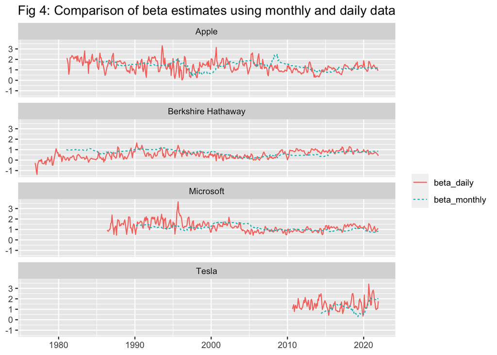

```r
beta <- beta_monthly |>
  full_join(beta_daily, join_by(permno, month)) |>
  arrange(permno, month)

beta |>
  inner_join(examples, join_by(permno)) |>
  pivot_longer(cols = c(beta_monthly, beta_daily)) |>
  drop_na() |>
  ggplot(aes(
    x = month,
    y = value,
    color = name,
    linetype = name
    )) +
  geom_line() +
  facet_wrap(~company, ncol = 1) +
  labs(
    x = NULL, y = NULL, color = NULL, linetype = NULL,
    title = "Fig 4: Comparison of beta estimates using monthly and daily data"
  )
```

[图 4](https://www-tidy--finance-org.translate.goog/r/beta-estimation.html?_x_tr_sl=auto&_x_tr_tl=zh-CN&_x_tr_hl=zh-CN&_x_tr_pto=wapp#fig-604)中的估计值看起来符合预期。正如您所看到的，它实际上取决于估计窗口和数据频率，您的 Beta 估计结果如何。

最后，我们将估计值写入数据库，以便我们可以在后面的章节中使用它们。

```r
dbWriteTable(tidy_finance,
  "beta",
  value = beta,
  overwrite = TRUE
)
```

每当您进行某种估计时，进行粗略的合理性测试也是有意义的。一个可能的检查是绘制随着时间的推移具有贝塔估计值的股票份额。这种描述有助于我们发现数据准备或估计过程中的潜在错误。例如，假设我们的输出存在差距，我们没有任何贝塔值。在这种情况下，我们必须返回并检查之前的所有步骤以找出问题所在。

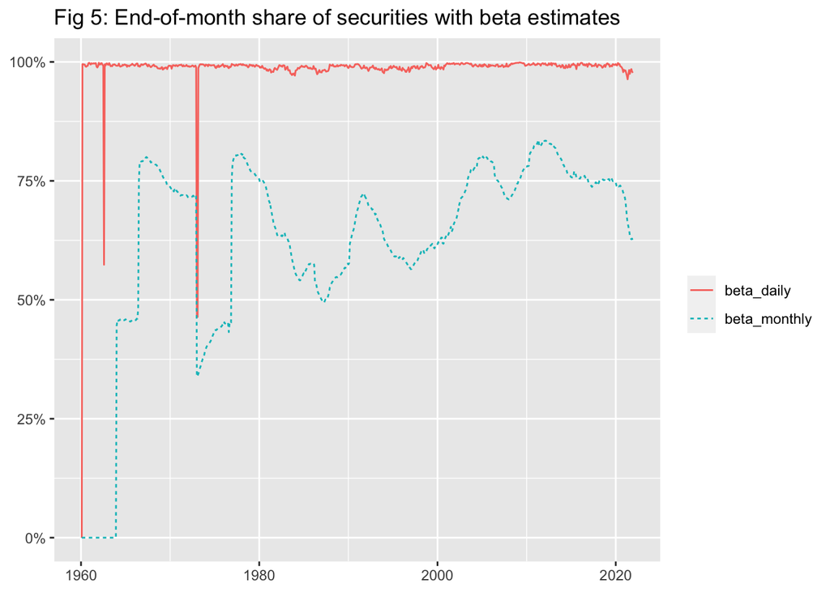

```r
beta_long <- crsp_monthly |>
  left_join(beta, join_by(permno, month)) |>
  pivot_longer(cols = c(beta_monthly, beta_daily))

beta_long |>
  group_by(month, name) |>
  summarize(share = sum(!is.na(value)) / n(),
            .groups = "drop") |>
  ggplot(aes(
    x = month,
    y = share,
    color = name,
    linetype = name
    )) +
  geom_line() +
  scale_y_continuous(labels = percent) +
  labs(
    x = NULL, y = NULL, color = NULL, linetype = NULL,
    title = "Fig 5: End-of-month share of securities with beta estimates"
  ) +
  coord_cartesian(ylim = c(0, 1))
```

[图5](https://www-tidy--finance-org.translate.goog/r/beta-estimation.html?_x_tr_sl=auto&_x_tr_tl=zh-CN&_x_tr_hl=zh-CN&_x_tr_pto=wapp#fig-605)没有表明任何问题，所以让我们继续进行下一步检查。

我们还鼓励大家经常查看变量的分布汇总统计数据。查看此类表格时，您可以轻松发现异常值或奇怪的分布。

```r
beta_long |>
  select(name, value) |>
  drop_na() |>
  group_by(name) |>
  summarize(
    mean = mean(value),
    sd = sd(value),
    min = min(value),
    q05 = quantile(value, 0.05),
    q50 = quantile(value, 0.50),
    q95 = quantile(value, 0.95),
    max = max(value),
    n = n()
  )
```

```
## # A tibble: 2 × 9
##   name          mean    sd   min    q05   q50   q95   max       n
##   <chr>        <dbl> <dbl> <dbl>  <dbl> <dbl> <dbl> <dbl>   <int>
## 1 beta_daily   0.749 0.926 -43.7 -0.447 0.686  2.23  56.6 3233745
## 2 beta_monthly 1.10  0.713 -13.0  0.125 1.03   2.32  10.3 2102854
```

对于这两个估计程序来说，汇总统计数据看起来也是合理的。

最后，由于我们对同一理论对象有两个不同的估计量，因此我们期望估计量至少应呈正相关（尽管并不完美，因为估计量基于不同的采样周期和频率）。

```r
beta |>
  select(beta_daily, beta_monthly) |>
  cor(use = "complete.obs")
```

```
##              beta_daily beta_monthly
## beta_daily     1.000000     0.322736
## beta_monthly   0.322736     1.000000
```

事实上，我们发现我们的贝塔估计值之间存在正相关关系。在后续章节中，我们主要使用基于每月数据的估计，因为由于每日数据可能出现潜在的内存限制，大多数读者应该能够复制它们。